# Статистический анализ данных (задание 1)

Имя Фамилия, номер группы

В данном задании необходимо проанализировать поведение схожих критериев — Фишера и Зигеля-Тьюки (без центрирования выборок) — для задачи проверки гипотезы о совпадении дисперсий двух выборок из нормальных распределений. Для каждого из критериев требуется построить графики зависимости достигаемых уровней значимости и оценок мощностей от параметров и показать, в каких областях изменения параметров предпочтительнее использовать тот или иной критерий.

Исходные параметры эксперимента выглядят следующим образом: $X_1^n, \;\; X_1 \sim N(0, 1),\;\;X_2^n, \;\; X_2 \sim N(\mu, \sigma^2);$ $H_0\,:\, \mathbb{D}X_1 = \mathbb{D}X_2,$ $H_1\,:\, \mathbb{D}X_1 \neq \mathbb{D}X_2;$ $\mu=0\,:\,0.05\,:\,5, \;\; \sigma = 0.5\,:\,0.01\,:\,2, \;\; n=20.$

Добавим в текущее рабочее пространство функцию `siegel.tukey`, позволяющую использовать критерий Зигеля-Тьюки:

```r
source('siegel.tukey.R')
```

Установим необходимые параметры эксперимента и создадим нужные переменные для сохранения достигаемых уровней значимости и оценок мощностей при различных значениях параметров:

```r
nsample <- 20
mus     <- seq(0,   5, by=0.05)
sigmas  <- seq(0.5, 2, by=0.01)
N       <- length(mus)
M       <- length(sigmas)
grid    <- expand.grid(x=mus, y=sigmas)
```

Запустим алгоритм, который позволит вычислить все необходимые значения:

```r
N_exps  <- 1
PV_F    <- rep(0, N * M)
PV_ST   <- rep(0, N * M)
Pow_F   <- rep(0, N * M)
Pow_ST  <- rep(0, N * M)

for (iter in 1:N_exps) {
    X1 <- rnorm(nsample, mean = 0, sd = 1)
    X2n <- matrix(rnorm(nsample * length(grid$x), grid$x, grid$y), nrow=length(grid$x))
    splitList <- split(X2n, 1:nrow(X2n))

    TMP   <- unlist(lapply(splitList, function(Y) var.test(X1, Y)$p.value))
    PV_F  <- PV_F + TMP

    TMP    <- unlist(lapply(splitList, function(Y) siegel.tukey(X1, Y)$p.value))
    PV_ST  <- PV_ST + TMP
}
PV_F   <- matrix(PV_F   / N_exps, nrow=N, ncol=M)
PV_ST  <- matrix(PV_ST  / N_exps, nrow=N, ncol=M)
```

Полученные достигаемые уровни значимости при разных значениях параметров $\mu$ и $\sigma$:

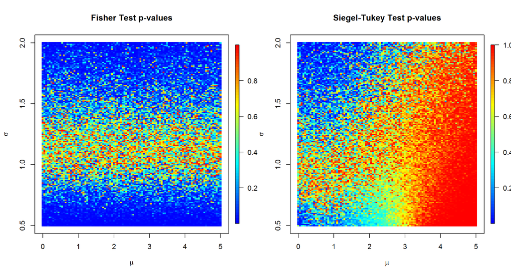

```r
library(fields)

par(mfrow=c(1,2))
image.plot(matrix(grid$x, nrow=N, ncol=M), matrix(grid$y, nrow=N, ncol=M), PV_F,
           col = colorRampPalette(c("blue", "cyan", "yellow", "red"))(1024),
           main="Fisher Test p-values", xlab=expression(mu), ylab=expression(sigma))

image.plot(matrix(grid$x, nrow=N, ncol=M), matrix(grid$y, nrow=N, ncol=M), PV_ST,
           col = colorRampPalette(c("blue", "cyan", "yellow", "red"))(1024),
           main="Siegel-Tukey Test p-values", xlab=expression(mu), ylab=expression(sigma))
```

Однократная генерация пары выборок не позволяет точно оценить границы области, где нулевая гипотеза отклоняется, поэтому необходимо усреднение по большому числу экспериментов. Возьмём 1000 повторений:

```r
N_exps <- 1000
PV_F   <- rep(0, N * M)
PV_ST  <- rep(0, N * M)
Pow_F  <- rep(0, N * M)
Pow_ST <- rep(0, N * M)

for (iter in 1:N_exps) {
    X1  <- rnorm(nsample, mean = 0, sd = 1)
    X2n <- matrix(rnorm(nsample * length(grid$x), grid$x, grid$y), nrow=length(grid$x))
    splitList <- split(X2n, 1:nrow(X2n))

    TMP   <- unlist(lapply(splitList, function(Y) var.test(X1, Y)$p.value))
    PV_F  <- PV_F + TMP
    Pow_F <- Pow_F + (TMP <= 0.05)

    TMP    <- unlist(lapply(splitList, function(Y) siegel.tukey(X1, Y)$p.value))
    PV_ST  <- PV_ST + TMP
    Pow_ST <- Pow_ST + (TMP <= 0.05)
}
PV_F   <- matrix(PV_F   / N_exps, nrow=N, ncol=M)
PV_ST  <- matrix(PV_ST  / N_exps, nrow=N, ncol=M)
Pow_F  <- matrix(Pow_F  / N_exps, nrow=N, ncol=M)
Pow_ST <- matrix(Pow_ST / N_exps, nrow=N, ncol=M)
```

Посмотрим сначала на средние достигаемые уровни значимости и мощности критериев при $\mu=0$, когда предположения обоих выполняются:

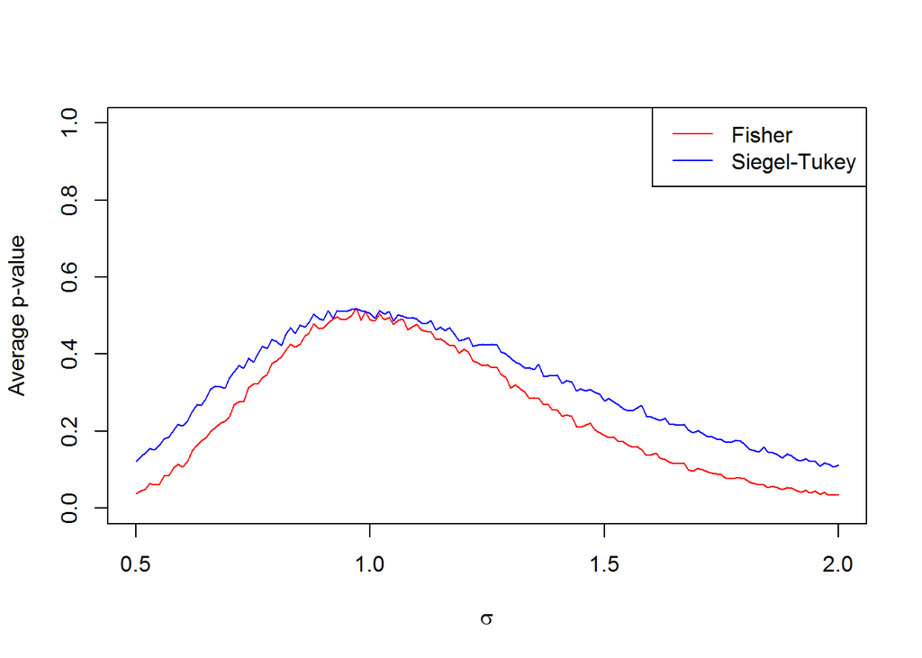

```r
par(mfrow=c(1,1))
plot(sigmas, PV_F[1,],   col="red", type="l", xlab=expression(sigma), ylab="Average p-value", main="",
     ylim=c(0,1))
lines(sigmas, PV_ST[1,], col="blue")
legend("topright", c("Fisher", "Siegel-Tukey"), lty=c(1,1), col=c("red", "blue"))
grid()
```

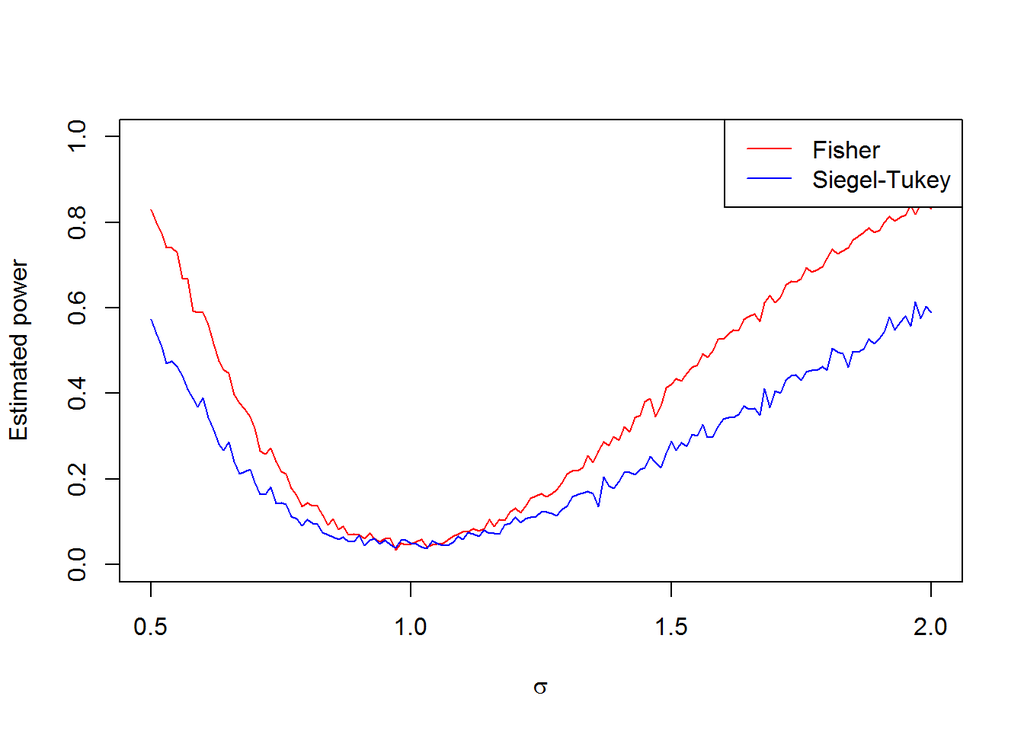

```r
plot(sigmas, Pow_F[1,],   col="red", type="l", xlab=expression(sigma), ylab="Estimated power", main="",
     ylim=c(0,1))
lines(sigmas, Pow_ST[1,], col="blue")
legend("topright", c("Fisher", "Siegel-Tukey"), lty=c(1,1), col=c("red", "blue"))
grid()
```

Средние достигаемые уровни значимости и оценки мощности критериев при различных значениях параметров $\mu$ и $\sigma$:

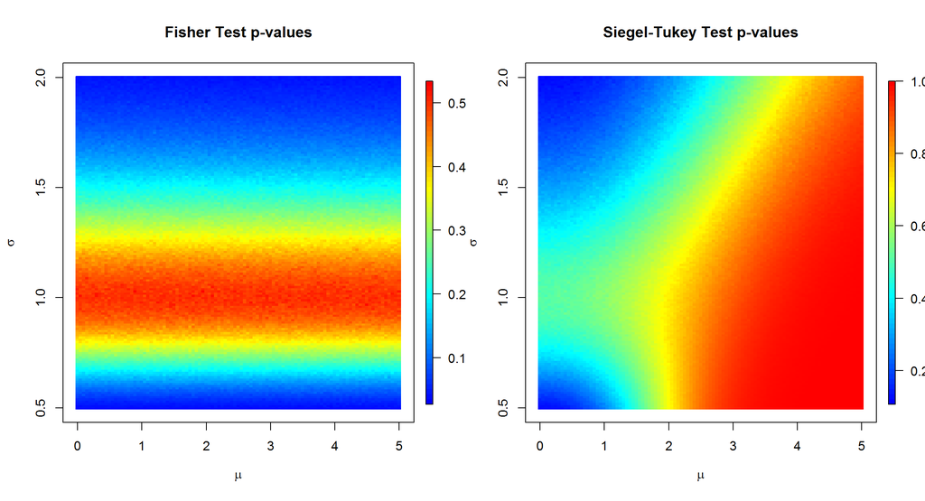

```r
par(mfrow=c(1,2))
image.plot(matrix(grid$x, nrow=N, ncol=M), matrix(grid$y, nrow=N, ncol=M), PV_F,
           col = colorRampPalette(c("blue", "cyan", "yellow", "red"))(1024),
           main="Fisher Test p-values", xlab=expression(mu), ylab=expression(sigma))

image.plot(matrix(grid$x, nrow=N, ncol=M), matrix(grid$y, nrow=N, ncol=M), PV_ST,
           col = colorRampPalette(c("blue", "cyan", "yellow", "red"))(1024),
           main="Siegel-Tukey Test p-values", xlab=expression(mu), ylab=expression(sigma))
```

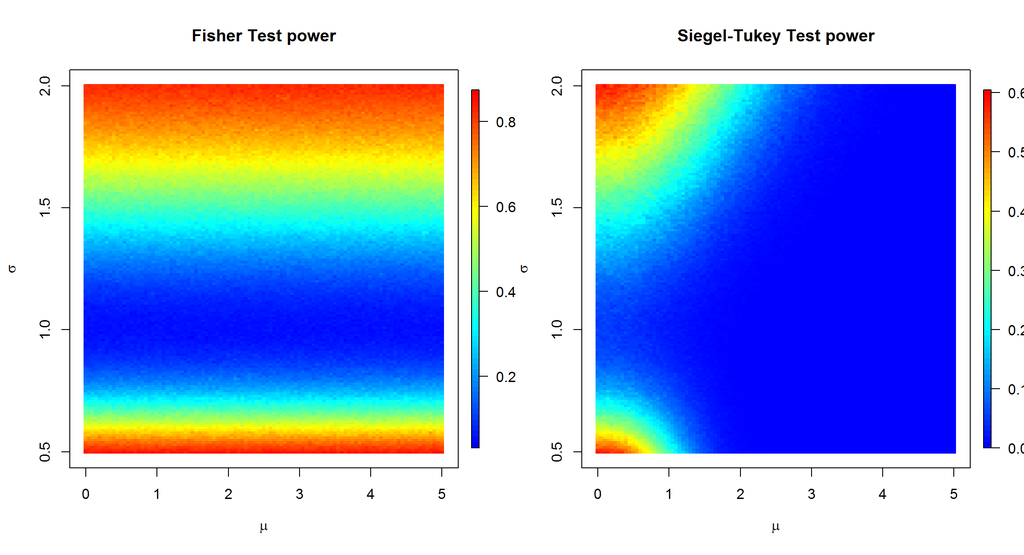

```r
image.plot(matrix(grid$x, nrow=N, ncol=M), matrix(grid$y, nrow=N, ncol=M), Pow_F,
           col = colorRampPalette(c("blue", "cyan", "yellow", "red"))(1024),
           main="Fisher Test power", xlab=expression(mu), ylab=expression(sigma))

image.plot(matrix(grid$x, nrow=N, ncol=M), matrix(grid$y, nrow=N, ncol=M), Pow_ST,
           col = colorRampPalette(c("blue", "cyan", "yellow", "red"))(1024),
           main="Siegel-Tukey Test power", xlab=expression(mu), ylab=expression(sigma))
```

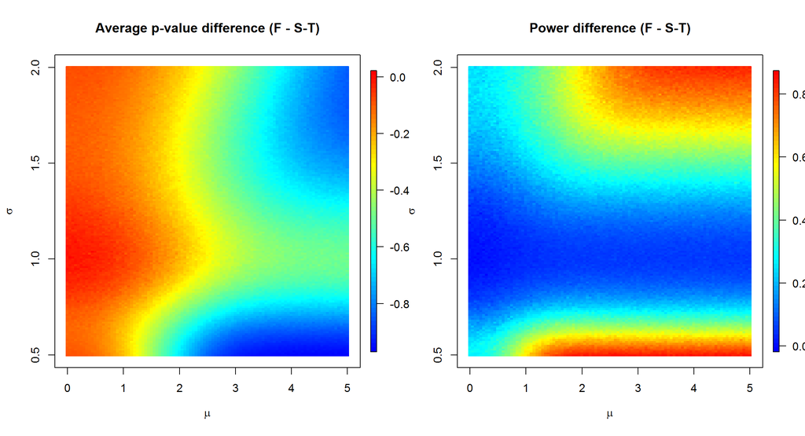

```r
image.plot(matrix(grid$x, nrow=N, ncol=M), matrix(grid$y, nrow=N, ncol=M), PV_F - PV_ST,
           col = colorRampPalette(c("blue", "cyan", "yellow", "red"))(1024),
           main="Average p-value difference (F - S-T)", xlab=expression(mu), ylab=expression(sigma))

image.plot(matrix(grid$x, nrow=N, ncol=M), matrix(grid$y, nrow=N, ncol=M), Pow_F-Pow_ST,
           col = colorRampPalette(c("blue", "cyan", "yellow", "red"))(1024),
           main="Power difference (F - S-T)", xlab=expression(mu), ylab=expression(sigma))
```

Видно, что нарушение предположения о равенстве средних существенно влияет на критерий Зигеля-Тьюки: если при $\mu=0$ его мощность сравнима с мощностью критерия Фишера, то с увеличением $\mu$ средние достигаемые уровни значимости постепенно начинают расти, причём скорость роста определяется соотношением $\mu$ и $\sigma$. При $\frac{\mu}{\sqrt{\sigma}}> 3$ средние достигаемые уровни значимости близки к единице, а при $\frac{\mu}{\sqrt{\sigma}}> 1.5$ мощность близка к нулю для любых значений $\sigma$ в исследуемом диапазоне.

Чтобы оценить корректность критериев, посмотрим отдельно, как часто гипотеза о равенстве дисперсий отвергается при $\sigma=1$ (то есть, на частоту ошибок первого рода) при различных $\mu$.

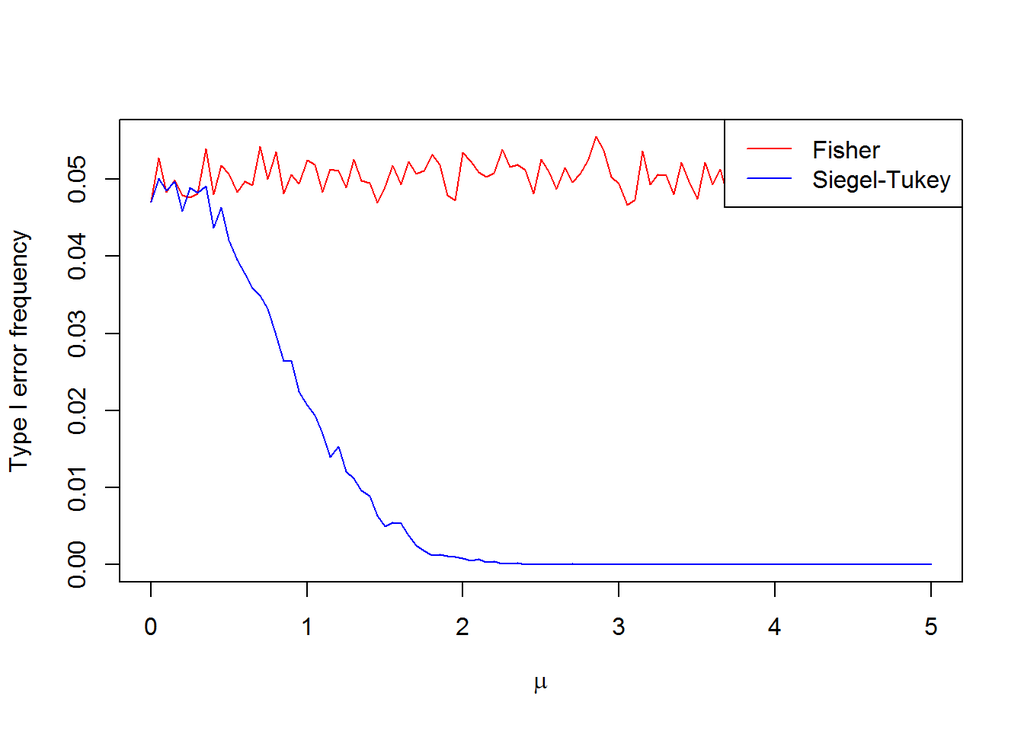

```r
N_exps <- 10000
T1_F   <- rep(0, N)
T1_ST  <- rep(0, N)

for (iter in 1:N_exps) {
    X1  <- rnorm(nsample, mean = 0, sd = 1)
    X2n <- matrix(rnorm(nsample * length(mus), mus, 1), nrow=length(mus))
    splitList <- split(X2n, 1:nrow(X2n))

    TMP   <- unlist(lapply(splitList, function(Y) var.test(X1, Y)$p.value))
    T1_F  <- T1_F + (TMP <= 0.05)

    TMP    <- unlist(lapply(splitList, function(Y) siegel.tukey(X1, Y)$p.value))
    T1_ST  <- T1_ST + (TMP <= 0.05)
}
T1_F  <- T1_F  / N_exps
T1_ST <- T1_ST / N_exps

par(mfrow=c(1,1))
plot(mus, T1_F,   col="red", type="l", xlab=expression(mu), ylab="Type I error frequency", main="",
     ylim=c(min(T1_F, T1_ST), max(T1_F, T1_ST)))
lines(mus, T1_ST, col="blue")
legend("topright", c("Fisher", "Siegel-Tukey"), lty=c(1,1), col=c("red", "blue"))
```

Таким образом, критерий Зигеля-Тьюки крайне чувствителен к сдвигу между распределениями, и в случае нарушения предположения о равенстве медиан случайных величин, из которых взяты сравниваемые выборки, его применение без центрирования выборок нецелесообразно.